# PID Taxation

Ernesto Carrella

April 10, 2017

## Sequential Depletion

Imagine there are two kinds of fish in the sea: reds and blues. They are geographically split so that it’s very easy for a fisher to decide what to catch.

[video not shown]

Blue fish sell for a higher price: 30$ a kg compared to 10$ a kg. With no regulations in place, most fishers target blue fish. Blue landings are unsustainable however and deplete quickly the blue biomass. Later agents mostly switch to fishing red. This is somewhat wasteful as the resource we value the most is completely consumed early on.

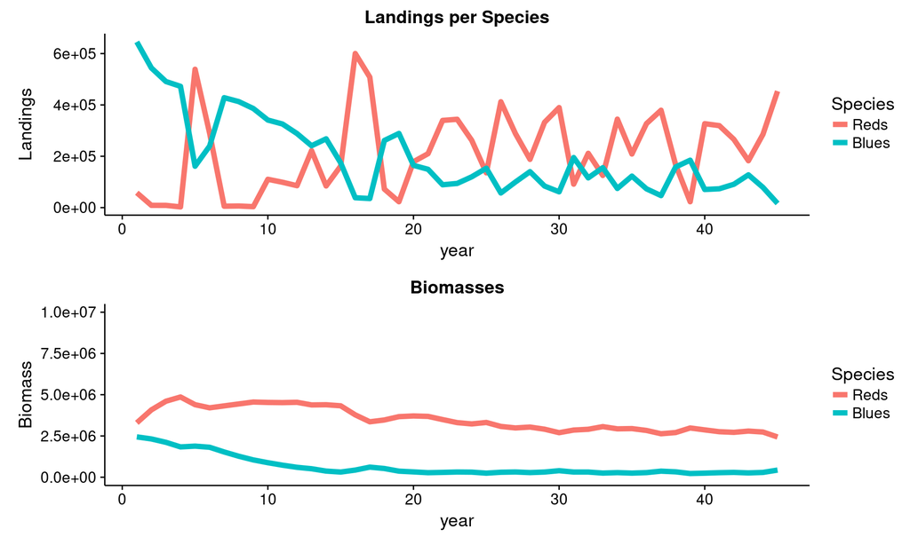

## Market - Based Policy

We would like to protect the blue species from overfishing. However:

- We can’t set quotas
- We can’t set protected areas
- We can’t enforce seasons
- We do not know biomass at any point

The only avenue available is taxation (or any other form of intervention that lowers blue ex-vessel prices). Imagine that we decide that we would like the fishery to catch about 600 units of blue fish a day (this number is more or less arbitrary). Catching more than 600 is bad (because it leads to over-exploitation), catching less than 600 is also bad (because it is unprofitable).

Now the key idea here is that any single fixed tax $\tau$ will not work very well. This is because taxation tends to incentivate fishers to switch to catching reds. However when red biomass starts depleting $\tau$ is not enough to keep people away from blue stocks. What is needed instead is a **closed-loop** policy where $\tau$ is modified daily such that:
$$\tau = a e_t + b \sum_{i=0}^T e_{t-i}$$
$$e_t = \text{Landings}_t - 600$$
Which is a very simple and generic PI controller (basically a thermostat): we do not figure out what the $\tau$ is, we just keep increasing it whenever landings are above target and decreasing it when they are below.
The parameters $a$ and $b$ defines how quickly and how aggressively we adapt.

“Autopilot” policies like these have a bad reputation (see Punt et al, 2014) for a good reason: it’s very easy to pick up noise and make decisions that are quite poor. For example if $a$ and $b$ are set somewhat randomly we get the following dynamics:

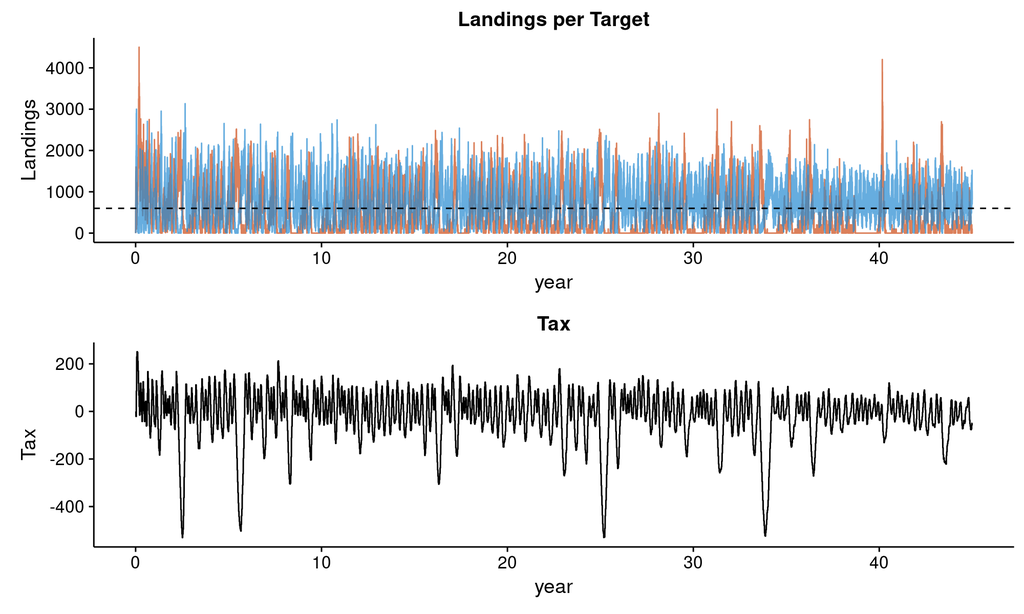

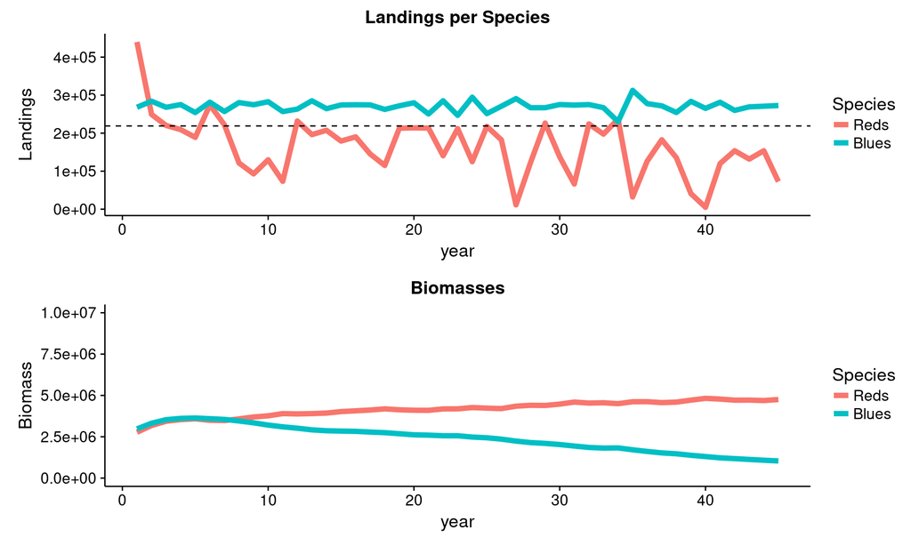

That is we get a completely crazy taxation: sometimes taxing 200$ a fish worth 30$ and sometimes offering subsidies of 400$ and we overall fail to hit our landing targets.  
What is going on?  
The fact is that our decision rule is based on noisy and delayed data. Landings themselves are perfectly observed but they are a noisy indicator of what is actually targeted (some fishers might have gone south looking for blue fish but got unlucky, for example). Moreover it takes time for the tax incentive to drive fishers to switch location.

How do we fix it?  
We need to find the “best” paramters $a$ and $b$ that adjust taxation gently to avoid over-reacting to any deviation from optimal landings. Searching for $a$ and $b$ is just another banal Bayesian Optimization however; once we do that we can check the new dynamics:

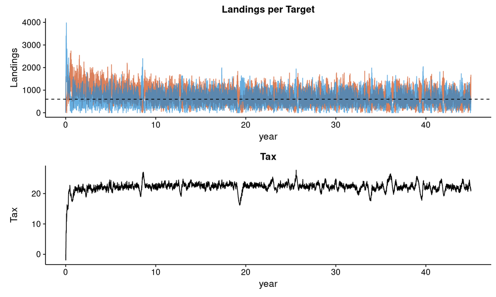

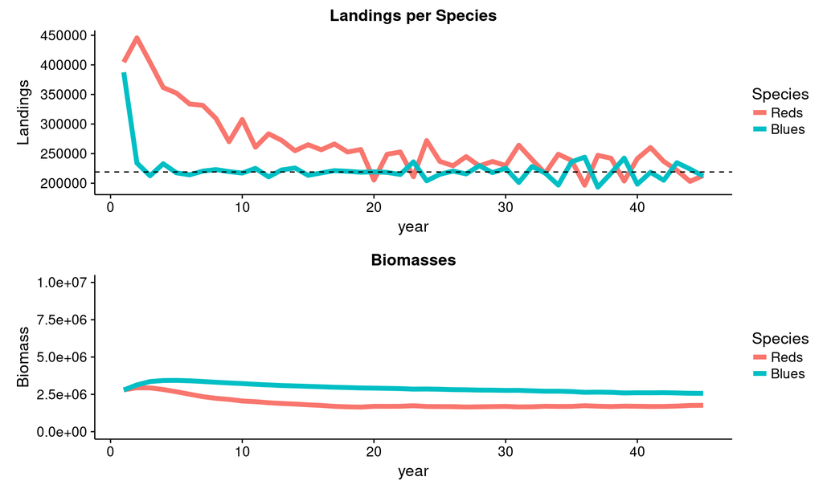